# Reproducible Research: Peer Assessment 1

Adolfo Zignago

1/26/2018

## Loading and preprocessing the data

The data for this assignment can be downloaded from the course web site: Dataset: [Activity monitoring data](https://d396qusza40orc.cloudfront.net/repdata%2Fdata%2Factivity.zip) [52K]

```r
fileURL = "https://d396qusza40orc.cloudfront.net/repdata%2Fdata%2Factivity.zip"
fileDest = "activity.zip"
if(!file.exists(fileDest)) {
        download.file(fileURL, fileDest, method = "curl", mode = "wb")
        activityfile <- unzip(fileDest)
} else {
        activityfile <- unzip(fileDest)
}

activityDataFile <- read.csv(activityfile, sep = ",")
head(activityDataFile)
```

```
##   steps       date interval
## 1    NA 2012-10-01        0
## 2    NA 2012-10-01        5
## 3    NA 2012-10-01       10
## 4    NA 2012-10-01       15
## 5    NA 2012-10-01       20
## 6    NA 2012-10-01       25
```

## What is mean total number of steps taken per day?

For this part of the assignment, you can ignore the missing values in the dataset.

```r
activityData <- na.omit(activityDataFile)
```

1. Calculate the total number of steps taken per day

```r
totalstepday <- aggregate(as.numeric(activityData[, "steps"]), by = list(activityData$date), sum)
colnames(totalstepday) <- c("date", "steps")
head(totalstepday, 20)
```

```
##          date steps
## 1  2012-10-02   126
## 2  2012-10-03 11352
## 3  2012-10-04 12116
## 4  2012-10-05 13294
## 5  2012-10-06 15420
## 6  2012-10-07 11015
## 7  2012-10-09 12811
## 8  2012-10-10  9900
## 9  2012-10-11 10304
## 10 2012-10-12 17382
## 11 2012-10-13 12426
## 12 2012-10-14 15098
## 13 2012-10-15 10139
## 14 2012-10-16 15084
## 15 2012-10-17 13452
## 16 2012-10-18 10056
## 17 2012-10-19 11829
## 18 2012-10-20 10395
## 19 2012-10-21  8821
## 20 2012-10-22 13460
```

2. If you do not understand the difference between a histogram and a barplot, research the difference between them. Make a histogram of the total number of steps taken each day

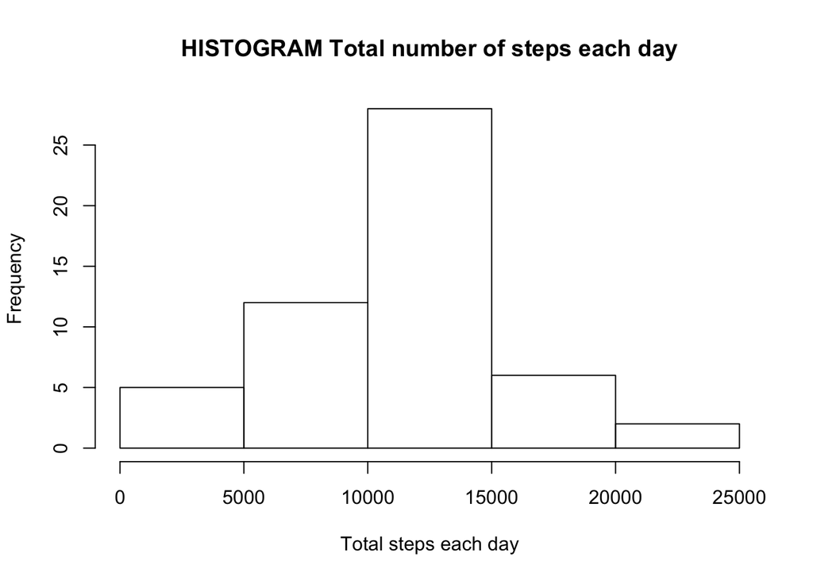

```r
hist(totalstepday$steps, main = "HISTOGRAM Total number of steps each day", xlab = "Total steps each day")
```

3. Calculate and report the mean and median of the total number of steps taken per day

```r
mean(as.numeric(totalstepday[, "steps"]), na.rm = TRUE)
```

```
## [1] 10766.19
```

```r
median(as.numeric(totalstepday[, "steps"]), na.rm = TRUE)
```

```
## [1] 10765
```

```r
summary(totalstepday)
```

```
##          date        steps
##  2012-10-02: 1   Min.   :   41
##  2012-10-03: 1   1st Qu.: 8841
##  2012-10-04: 1   Median :10765
##  2012-10-05: 1   Mean   :10766
##  2012-10-06: 1   3rd Qu.:13294
##  2012-10-07: 1   Max.   :21194
##  (Other)   :47
```

## What is the average daily activity pattern?

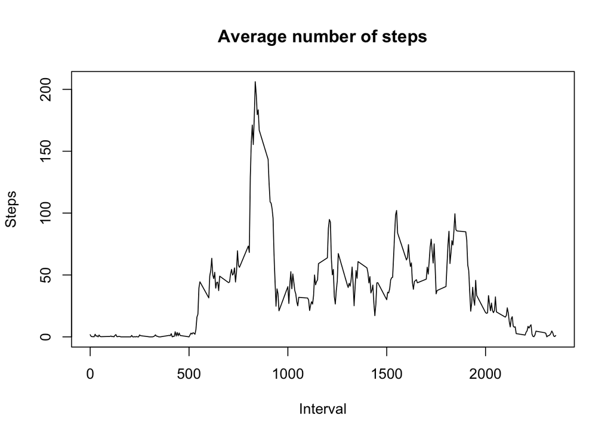

```r
totalinterval <- aggregate(steps ~ interval, activityData, mean)

plot(totalinterval$interval, totalinterval$steps, type="l", xlab = "Interval", ylab = "Steps", main = "Average number of steps")
```

2. Which 5-minute interval, on average across all the days in the dataset, contains the maximum number of steps?

```r
totalinterval[which.max(totalinterval$steps), ]
```

```
##     interval    steps
## 104      835 206.1698
```

## Imputing missing values

```r
sum(is.na(activityDataFile$steps))
```

```
## [1] 2304
```

2. Devise a strategy for filling in all of the missing values in the dataset. The strategy does not need to be sophisticated. For example, you could use the mean/median for that day, or the mean for that 5-minute interval, etc.

```r
avginterval <- aggregate(steps ~ interval, activityDataFile, mean)
```

3. Create a new dataset that is equal to the original dataset but with the missing data filled in.

```r
newactivityData <- activityDataFile

for (i in 1:nrow(newactivityData)) {
  if (is.na(newactivityData[i, "steps"])) {
          intervalData <- newactivityData[i, "interval"]
          intervalRow <- which(avginterval$interval == intervalData)
          newactivityData[i, "steps"] <- avginterval[intervalRow, "steps"]
  }
}
head(newactivityData)
```

```
##       steps       date interval
## 1 1.7169811 2012-10-01        0
## 2 0.3396226 2012-10-01        5
## 3 0.1320755 2012-10-01       10
## 4 0.1509434 2012-10-01       15
## 5 0.0754717 2012-10-01       20
## 6 2.0943396 2012-10-01       25
```

4. Make a histogram of the total number of steps taken each day and Calculate and report the mean and median total number of steps taken per day. Do these values differ from the estimates from the first part of the assignment? What is the impact of imputing missing data on the estimates of the total daily number of steps?

```r
newtotalstepday <- aggregate(as.numeric(newactivityData[, "steps"]), by = list(newactivityData$date), sum)
colnames(newtotalstepday) <- c("date", "steps")
head(newtotalstepday, 20)
```

```
##          date    steps
## 1  2012-10-01 10766.19
## 2  2012-10-02   126.00
## 3  2012-10-03 11352.00
## 4  2012-10-04 12116.00
## 5  2012-10-05 13294.00
## 6  2012-10-06 15420.00
## 7  2012-10-07 11015.00
## 8  2012-10-08 10766.19
## 9  2012-10-09 12811.00
## 10 2012-10-10  9900.00
## 11 2012-10-11 10304.00
## 12 2012-10-12 17382.00
## 13 2012-10-13 12426.00
## 14 2012-10-14 15098.00
## 15 2012-10-15 10139.00
## 16 2012-10-16 15084.00
## 17 2012-10-17 13452.00
## 18 2012-10-18 10056.00
## 19 2012-10-19 11829.00
## 20 2012-10-20 10395.00
```

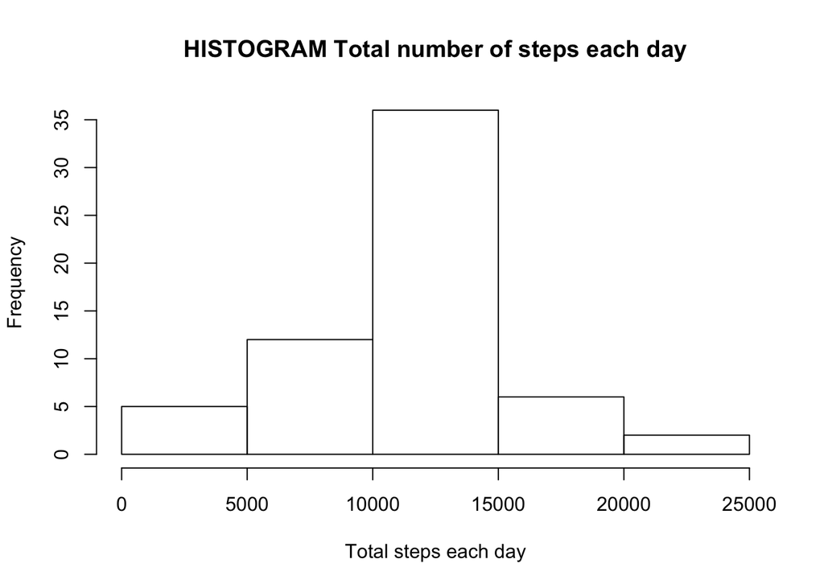

```r
hist(newtotalstepday$steps, main = "HISTOGRAM Total number of steps each day", xlab = "Total steps each day")
```

```r
mean(as.numeric(newtotalstepday[, "steps"]), na.rm = TRUE)
```

```
## [1] 10766.19
```

```r
median(as.numeric(newtotalstepday[, "steps"]), na.rm = TRUE)
```

```
## [1] 10766.19
```

```r
summary(newtotalstepday)
```

```
##          date        steps
##  2012-10-01: 1   Min.   :   41
##  2012-10-02: 1   1st Qu.: 9819
##  2012-10-03: 1   Median :10766
##  2012-10-04: 1   Mean   :10766
##  2012-10-05: 1   3rd Qu.:12811
##  2012-10-06: 1   Max.   :21194
##  (Other)   :55
```

## Are there differences in activity patterns between weekdays and weekends?

1. Create a new factor variable in the dataset with two levels – “weekday” and “weekend” indicating whether a given date is a weekday or weekend day.

```r
newactivityData$date <- as.Date(newactivityData$date)
listweekdays <- c('Monday', 'Tuesday', 'Wednesday', 'Thursday', 'Friday')
newactivityData$wday <- c('weekend', 'weekday')[(weekdays(newactivityData$date) %in% listweekdays)+1L]
```

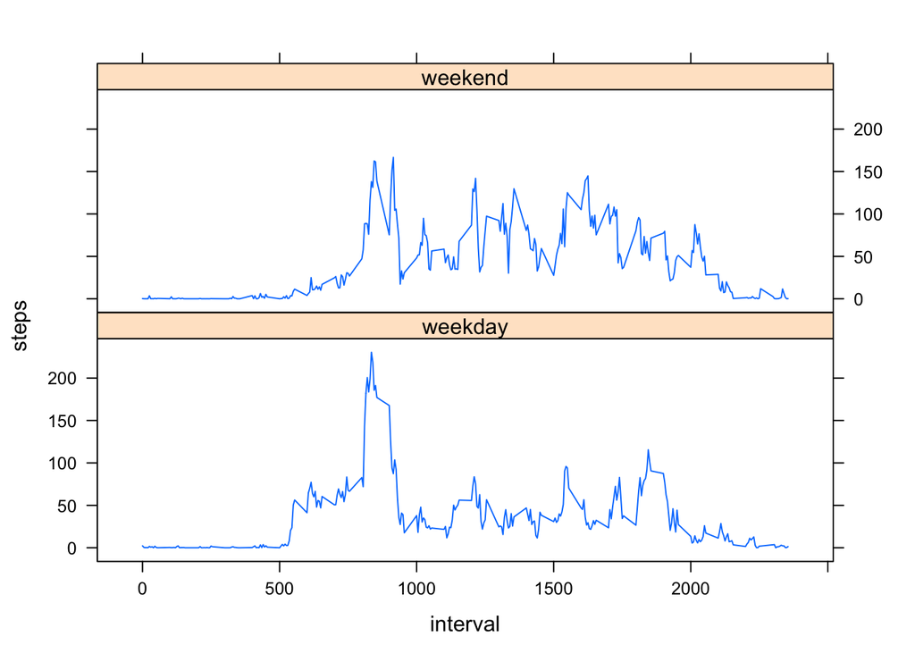

```r
activityDataWday <- aggregate(steps ~ interval + wday, newactivityData, mean)
library(lattice)
xyplot(steps ~ interval | factor(wday), data=activityDataWday, type='l', layout=c(1,2))
```